# `tabula-rasa/py/sklearn/C.ipynb`

My solutions for part C of /12_mod_scikitlearn/05-Exercises.ipynb

## 🐍 Python imports 🐍

```python
import os

import pandas as pd
import matplotlib.pyplot as plt
import seaborn as sns
import numpy as np
```

```python
from sklearn.model_selection import train_test_split
from sklearn import preprocessing
from sklearn.neighbors import KNeighborsClassifier
from sklearn import metrics
```

## 🎨 Styling 🎨

```python
# plt.style.use("./../../style/ai.mplstyle")

path = os.path.join(".", "..", "..", "style", "ai.mplstyle")
plt.style.use(path)
```

## 📁 Data loading 📁

```python
# pd.read_csv("./../../data/iris.csv")

path = os.path.join(".", "..", "..", "data", "iris.csv")
df = pd.read_csv(path)

df
```

|  | Id | SepalLengthCm | SepalWidthCm | PetalLengthCm | PetalWidthCm | Species |
| --- | --- | --- | --- | --- | --- | --- |
| 0 | 1 | 5.1 | 3.5 | 1.4 | 0.2 | Iris-setosa |
| 1 | 2 | 4.9 | 3.0 | 1.4 | 0.2 | Iris-setosa |
| 2 | 3 | 4.7 | 3.2 | 1.3 | 0.2 | Iris-setosa |
| 3 | 4 | 4.6 | 3.1 | 1.5 | 0.2 | Iris-setosa |
| 4 | 5 | 5.0 | 3.6 | 1.4 | 0.2 | Iris-setosa |
| ... | ... | ... | ... | ... | ... | ... |
| 145 | 146 | 6.7 | 3.0 | 5.2 | 2.3 | Iris-virginica |
| 146 | 147 | 6.3 | 2.5 | 5.0 | 1.9 | Iris-virginica |
| 147 | 148 | 6.5 | 3.0 | 5.2 | 2.0 | Iris-virginica |
| 148 | 149 | 6.2 | 3.4 | 5.4 | 2.3 | Iris-virginica |
| 149 | 150 | 5.9 | 3.0 | 5.1 | 1.8 | Iris-virginica |

150 rows × 6 columns

## ❄ Exercise 1.

Write a Python program to split the iris dataset into its attributes (X) and labels (y). The X variable contains the first four columns (i.e. attributes) and y contains the labels of the dataset.

```python
X = df.drop(columns=["Id", "Species"], inplace=False)

X
```

|  | SepalLengthCm | SepalWidthCm | PetalLengthCm | PetalWidthCm |
| --- | --- | --- | --- | --- |
| 0 | 5.1 | 3.5 | 1.4 | 0.2 |
| 1 | 4.9 | 3.0 | 1.4 | 0.2 |
| 2 | 4.7 | 3.2 | 1.3 | 0.2 |
| 3 | 4.6 | 3.1 | 1.5 | 0.2 |
| 4 | 5.0 | 3.6 | 1.4 | 0.2 |
| ... | ... | ... | ... | ... |
| 145 | 6.7 | 3.0 | 5.2 | 2.3 |
| 146 | 6.3 | 2.5 | 5.0 | 1.9 |
| 147 | 6.5 | 3.0 | 5.2 | 2.0 |
| 148 | 6.2 | 3.4 | 5.4 | 2.3 |
| 149 | 5.9 | 3.0 | 5.1 | 1.8 |

150 rows × 4 columns

```python
Y = df["Species"]

Y
```

```
0         Iris-setosa
1         Iris-setosa
2         Iris-setosa
3         Iris-setosa
4         Iris-setosa
            ...
145    Iris-virginica
146    Iris-virginica
147    Iris-virginica
148    Iris-virginica
149    Iris-virginica
Name: Species, Length: 150, dtype: object
```

## 🌸 Exercise 2.

```python
X_train, X_test, Y_train, Y_test = train_test_split(
    X, Y, test_size=0.30, random_state=2022
)
```

```python
X_train
```

|  | SepalLengthCm | SepalWidthCm | PetalLengthCm | PetalWidthCm |
| --- | --- | --- | --- | --- |
| 136 | 6.3 | 3.4 | 5.6 | 2.4 |
| 102 | 7.1 | 3.0 | 5.9 | 2.1 |
| 120 | 6.9 | 3.2 | 5.7 | 2.3 |
| 3 | 4.6 | 3.1 | 1.5 | 0.2 |
| 149 | 5.9 | 3.0 | 5.1 | 1.8 |
| ... | ... | ... | ... | ... |
| 24 | 4.8 | 3.4 | 1.9 | 0.2 |
| 18 | 5.7 | 3.8 | 1.7 | 0.3 |
| 88 | 5.6 | 3.0 | 4.1 | 1.3 |
| 112 | 6.8 | 3.0 | 5.5 | 2.1 |
| 125 | 7.2 | 3.2 | 6.0 | 1.8 |

105 rows × 4 columns

```python
Y_train
```

```
136     Iris-virginica
102     Iris-virginica
120     Iris-virginica
3          Iris-setosa
149     Iris-virginica
            ...
24         Iris-setosa
18         Iris-setosa
88     Iris-versicolor
112     Iris-virginica
125     Iris-virginica
Name: Species, Length: 105, dtype: object
```

```python
X_test
```

|  | SepalLengthCm | SepalWidthCm | PetalLengthCm | PetalWidthCm |
| --- | --- | --- | --- | --- |
| 128 | 6.4 | 2.8 | 5.6 | 2.1 |
| 105 | 7.6 | 3.0 | 6.6 | 2.1 |
| 30 | 4.8 | 3.1 | 1.6 | 0.2 |
| 137 | 6.4 | 3.1 | 5.5 | 1.8 |
| 17 | 5.1 | 3.5 | 1.4 | 0.3 |
| 8 | 4.4 | 2.9 | 1.4 | 0.2 |
| 79 | 5.7 | 2.6 | 3.5 | 1.0 |
| 80 | 5.5 | 2.4 | 3.8 | 1.1 |
| 0 | 5.1 | 3.5 | 1.4 | 0.2 |
| 67 | 5.8 | 2.7 | 4.1 | 1.0 |
| 91 | 6.1 | 3.0 | 4.6 | 1.4 |
| 131 | 7.9 | 3.8 | 6.4 | 2.0 |
| 58 | 6.6 | 2.9 | 4.6 | 1.3 |
| 100 | 6.3 | 3.3 | 6.0 | 2.5 |
| 118 | 7.7 | 2.6 | 6.9 | 2.3 |
| 5 | 5.4 | 3.9 | 1.7 | 0.4 |
| 95 | 5.7 | 3.0 | 4.2 | 1.2 |
| 129 | 7.2 | 3.0 | 5.8 | 1.6 |
| 103 | 6.3 | 2.9 | 5.6 | 1.8 |
| 92 | 5.8 | 2.6 | 4.0 | 1.2 |
| 36 | 5.5 | 3.5 | 1.3 | 0.2 |
| 43 | 5.0 | 3.5 | 1.6 | 0.6 |
| 111 | 6.4 | 2.7 | 5.3 | 1.9 |
| 39 | 5.1 | 3.4 | 1.5 | 0.2 |
| 115 | 6.4 | 3.2 | 5.3 | 2.3 |
| 133 | 6.3 | 2.8 | 5.1 | 1.5 |
| 121 | 5.6 | 2.8 | 4.9 | 2.0 |
| 20 | 5.4 | 3.4 | 1.7 | 0.2 |
| 68 | 6.2 | 2.2 | 4.5 | 1.5 |
| 146 | 6.3 | 2.5 | 5.0 | 1.9 |
| 38 | 4.4 | 3.0 | 1.3 | 0.2 |
| 82 | 5.8 | 2.7 | 3.9 | 1.2 |
| 89 | 5.5 | 2.5 | 4.0 | 1.3 |
| 1 | 4.9 | 3.0 | 1.4 | 0.2 |
| 74 | 6.4 | 2.9 | 4.3 | 1.3 |
| 6 | 4.6 | 3.4 | 1.4 | 0.3 |
| 34 | 4.9 | 3.1 | 1.5 | 0.1 |
| 69 | 5.6 | 2.5 | 3.9 | 1.1 |
| 44 | 5.1 | 3.8 | 1.9 | 0.4 |
| 59 | 5.2 | 2.7 | 3.9 | 1.4 |
| 147 | 6.5 | 3.0 | 5.2 | 2.0 |
| 66 | 5.6 | 3.0 | 4.5 | 1.5 |
| 57 | 4.9 | 2.4 | 3.3 | 1.0 |
| 107 | 7.3 | 2.9 | 6.3 | 1.8 |
| 139 | 6.9 | 3.1 | 5.4 | 2.1 |

```python
Y_test
```

```
128     Iris-virginica
105     Iris-virginica
30         Iris-setosa
137     Iris-virginica
17         Iris-setosa
8          Iris-setosa
79     Iris-versicolor
80     Iris-versicolor
0          Iris-setosa
67     Iris-versicolor
91     Iris-versicolor
131     Iris-virginica
58     Iris-versicolor
100     Iris-virginica
118     Iris-virginica
```

[output cut: 31 more lines]

## ❄ Exercise 3.

Write a Python program using Scikit-learn to convert Species columns in a numerical column of the iris dataframe. To encode this data map convert each value to a number. e.g. Iris-setosa:0, Iris-versicolor:1, and Iris-virginica:2. Now print the iris dataset into 80% train data and 20% test data. Out of total 150 records, the training set will contain 120 records and the test set contains 30 of those records. Print both datasets.

```python
le = preprocessing.LabelEncoder()

df["Species"] = le.fit_transform(df["Species"])
```

```python
X = df.drop(columns=["Id", "Species"], inplace=False)

X
```

|  | SepalLengthCm | SepalWidthCm | PetalLengthCm | PetalWidthCm |
| --- | --- | --- | --- | --- |
| 0 | 5.1 | 3.5 | 1.4 | 0.2 |
| 1 | 4.9 | 3.0 | 1.4 | 0.2 |
| 2 | 4.7 | 3.2 | 1.3 | 0.2 |
| 3 | 4.6 | 3.1 | 1.5 | 0.2 |
| 4 | 5.0 | 3.6 | 1.4 | 0.2 |
| ... | ... | ... | ... | ... |
| 145 | 6.7 | 3.0 | 5.2 | 2.3 |
| 146 | 6.3 | 2.5 | 5.0 | 1.9 |
| 147 | 6.5 | 3.0 | 5.2 | 2.0 |
| 148 | 6.2 | 3.4 | 5.4 | 2.3 |
| 149 | 5.9 | 3.0 | 5.1 | 1.8 |

150 rows × 4 columns

```python
Y = df["Species"]

Y
```

```
0      0
1      0
2      0
3      0
4      0
      ..
145    2
146    2
147    2
148    2
149    2
Name: Species, Length: 150, dtype: int64
```

```python
X_train, X_test, Y_train, Y_test = train_test_split(
    X, Y, test_size=0.20, random_state=2022
)
```

```python
X_train
```

|  | SepalLengthCm | SepalWidthCm | PetalLengthCm | PetalWidthCm |
| --- | --- | --- | --- | --- |
| 38 | 4.4 | 3.0 | 1.3 | 0.2 |
| 82 | 5.8 | 2.7 | 3.9 | 1.2 |
| 89 | 5.5 | 2.5 | 4.0 | 1.3 |
| 1 | 4.9 | 3.0 | 1.4 | 0.2 |
| 74 | 6.4 | 2.9 | 4.3 | 1.3 |
| ... | ... | ... | ... | ... |
| 24 | 4.8 | 3.4 | 1.9 | 0.2 |
| 18 | 5.7 | 3.8 | 1.7 | 0.3 |
| 88 | 5.6 | 3.0 | 4.1 | 1.3 |
| 112 | 6.8 | 3.0 | 5.5 | 2.1 |
| 125 | 7.2 | 3.2 | 6.0 | 1.8 |

120 rows × 4 columns

```python
Y_train
```

```
38     0
82     1
89     1
1      0
74     1
      ..
24     0
18     0
88     1
112    2
125    2
Name: Species, Length: 120, dtype: int64
```

```python
X_test
```

|  | SepalLengthCm | SepalWidthCm | PetalLengthCm | PetalWidthCm |
| --- | --- | --- | --- | --- |
| 128 | 6.4 | 2.8 | 5.6 | 2.1 |
| 105 | 7.6 | 3.0 | 6.6 | 2.1 |
| 30 | 4.8 | 3.1 | 1.6 | 0.2 |
| 137 | 6.4 | 3.1 | 5.5 | 1.8 |
| 17 | 5.1 | 3.5 | 1.4 | 0.3 |
| 8 | 4.4 | 2.9 | 1.4 | 0.2 |
| 79 | 5.7 | 2.6 | 3.5 | 1.0 |
| 80 | 5.5 | 2.4 | 3.8 | 1.1 |
| 0 | 5.1 | 3.5 | 1.4 | 0.2 |
| 67 | 5.8 | 2.7 | 4.1 | 1.0 |
| 91 | 6.1 | 3.0 | 4.6 | 1.4 |
| 131 | 7.9 | 3.8 | 6.4 | 2.0 |
| 58 | 6.6 | 2.9 | 4.6 | 1.3 |
| 100 | 6.3 | 3.3 | 6.0 | 2.5 |
| 118 | 7.7 | 2.6 | 6.9 | 2.3 |
| 5 | 5.4 | 3.9 | 1.7 | 0.4 |
| 95 | 5.7 | 3.0 | 4.2 | 1.2 |
| 129 | 7.2 | 3.0 | 5.8 | 1.6 |
| 103 | 6.3 | 2.9 | 5.6 | 1.8 |
| 92 | 5.8 | 2.6 | 4.0 | 1.2 |
| 36 | 5.5 | 3.5 | 1.3 | 0.2 |
| 43 | 5.0 | 3.5 | 1.6 | 0.6 |
| 111 | 6.4 | 2.7 | 5.3 | 1.9 |
| 39 | 5.1 | 3.4 | 1.5 | 0.2 |
| 115 | 6.4 | 3.2 | 5.3 | 2.3 |
| 133 | 6.3 | 2.8 | 5.1 | 1.5 |
| 121 | 5.6 | 2.8 | 4.9 | 2.0 |
| 20 | 5.4 | 3.4 | 1.7 | 0.2 |
| 68 | 6.2 | 2.2 | 4.5 | 1.5 |
| 146 | 6.3 | 2.5 | 5.0 | 1.9 |

```python
Y_test
```

```
128    2
105    2
30     0
137    2
17     0
8      0
79     1
80     1
0      0
67     1
91     1
131    2
58     1
100    2
118    2
```

[output cut: 16 more lines]

## 🌸 Exercise 4.

```python
knn = KNeighborsClassifier(n_neighbors=5)
knn.fit(X_train, Y_train)
Y_pred = knn.predict(X_test)

Y_pred
```

```
array([2, 2, 0, 2, 0, 0, 1, 1, 0, 1, 1, 2, 1, 2, 2, 0, 1, 2, 2, 1, 0, 0,
       2, 0, 2, 2, 2, 0, 1, 2])
```

```python
Y_pred == Y_test
```

```
128    True
105    True
30     True
137    True
17     True
8      True
79     True
80     True
0      True
67     True
91     True
131    True
58     True
100    True
118    True
```

[output cut: 16 more lines]

## ❄ Exercise 5.

Write a Python program using Scikit-learn to split the iris dataset into 80% train data and 20% test data. Out of total 150 records, the training set will contain 120 records and the test set contains 30 of those records. Train or fit the data into the model and calculate the accuracy of the model using the K Nearest Neighbor Algorithm.

```python
knn = KNeighborsClassifier(n_neighbors=3)
knn.fit(X_train, Y_train)
knn.score(X_test, Y_test)
```

```
0.9666666666666667
```

## 🌸 Exercise 6.

Write a Python program using Scikit-learn to split the iris dataset into 80% train data and 20% test data. Out of total 150 records, the training set will contain 120 records and the test set contains 30 of those records. Train or fit the data into the model and using the K Nearest Neighbor Algorithm calculate the performance for different values of k.

```python
for i in np.arange(1, 15):
    knn = KNeighborsClassifier(n_neighbors=i)
    knn.fit(X_train, Y_train)
    print(f"For k = {i} accuracy is {knn2.score(X_test, Y_test)}")
```

[output not shown]

## ❄ Exercise 7.

Write a Python program using Scikit-learn to split the iris dataset into 80% train data and 20% test data. Out of total 150 records, the training set will contain 120 records and the test set contains 30 of those records. Train or fit the data into the model and using the K Nearest Neighbor Algorithm and create a plot to present the performance for different values of k.

```python
a_index = list(range(1, 11))
a = pd.Series(dtype="float64")
```

```python
for i in list(range(1, 11)):
    model = KNeighborsClassifier(n_neighbors=i)
    model.fit(X_train, Y_train)
    prediction = model.predict(X_test)
    a = pd.concat([a, pd.Series(metrics.accuracy_score(prediction, Y_test))])
```

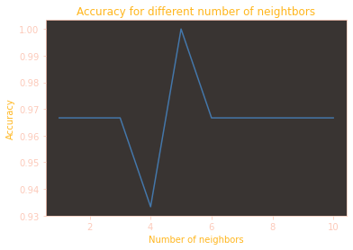

```python
plt.plot(a_index, a)

plt.xlabel("Number of neighbors")
plt.ylabel("Accuracy")
plt.title("Accuracy for different number of neightbors")

plt.show()
```

## 🌸 Exercise 8.

Write a Python program using Scikit-learn to split the iris dataset into 80% train data and 20% test data. Out of total 150 records, the training set will contain 120 records and the test set contains 30 of those records. Train or fit the data into the model and using the K Nearest Neighbor Algorithm and create a plot of k values vs accuracy.

## Solution

I modified the sample solution from [here](https://www.w3resource.com/machine-learning/scikit-learn/iris/python-machine-learning-k-nearest-neighbors-algorithm-exercise-8.php) so that it would work the training set variables I already generated.

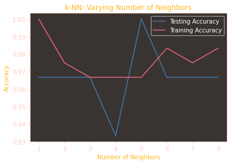

```python
knn.fit(X_train, Y_train)

no_neighbors = np.arange(1, 9)
train_accuracy = np.empty(len(no_neighbors))
test_accuracy = np.empty(len(no_neighbors))

for i, k in enumerate(no_neighbors):
    knn = KNeighborsClassifier(n_neighbors=k)
    knn.fit(X_train, Y_train)
    train_accuracy[i] = knn.score(X_train, Y_train)
    test_accuracy[i] = knn.score(X_test, Y_test)

plt.title("k-NN: Varying Number of Neighbors")
plt.plot(no_neighbors, test_accuracy, label="Testing Accuracy")
plt.plot(no_neighbors, train_accuracy, label="Training Accuracy")
plt.legend()
plt.xlabel("Number of Neighbors")
plt.ylabel("Accuracy")
plt.show()
```